# Making Venn and Euler Diagrams in R

##### A quick tutorial focusing on the different input formats and features of four Venn diagram packages.

**Not interested in using r? Click here to find links to non-programming, web-based solutions.**

#### Summary of packages in tutorial:

- **Venn**
  - Best use: **Fast venn diagrams**
  - Can make a venn diagram with up to **7 sets**.
- **VennDiagram**
  - Best use: **Publication worthy Venn diagrams**
  - Makes venn diagrams with up to **4 sets** or euler diagrams with up to 3 sets.
  - High resolution, options for customization
- **Eulerr**
  - Best use: **Euler diagrams**
  - Great default settings for making beautiful Euler diagrams
  - Watch out for missing relationships… Euler diagrams can be tricky sometimes.
- **Limma**
  - Best use: **Venn diagrams after microarray analysis**
  - Can make a venn diagram with up to **5 sets**.
  - Input is a count matrix rather than a list of IDs.

### Create Sample Dataset

##### This sample dataset consists of three samples and one control. All have the same genes (IDs) but different p-values (pval).

##### We want to find out how many genes are significant in each sample and how many of those genes overlap with the other samples.

```r
# Sample dataset ####
set.seed(23)

IDs <- paste("Gene", 1:100, sep = "_")

sample1 <- data.frame(IDs, pval = rnorm(length(IDs)))
sample2 <- data.frame(IDs, pval = rnorm(length(IDs)))
sample3 <- data.frame(IDs, pval = rnorm(length(IDs)))
control <- data.frame(IDs, pval = runif(length(IDs)), 0.01, 1)

# Get significant genes in each sample.
sig1 = sample1[sample1$pval < 0.05,]
sig2 = sample2[sample2$pval < 0.05,]
sig3 = sample3[sample3$pval < 0.05,]
sigcntl = control[control$pval < 0.05,]
```

### Venn

https://cran.r-project.org/web/packages/venn/venn.pdf

##### Venn can create a venn diagram with up to 7 sets and is quick and easy to use.

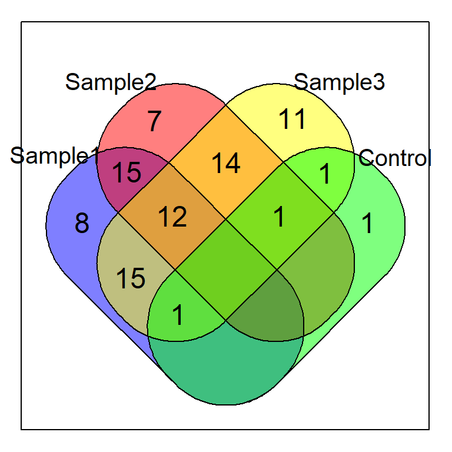

```r
library(venn)

# Input is list of IDs

# Get all significant genes (p values < 0.05)
ID_list <- list(Sample1=sample1$IDs[sample1$pval < 0.05],
                Sample2=sample2$IDs[sample2$pval < 0.05],
                Sample3=sample3$IDs[sample3$pval < 0.05],
                Control=control$IDs[control$pval < 0.05])

venn(ID_list,
     cexil = 1.5, # Change intersection labels
     cexsn = 1.25, # Change set name labels
     zcolor = c("blue", "red", "yellow", "green"), opacity = 0.5)
```

### VennDiagram

https://cran.r-project.org/web/packages/VennDiagram/VennDiagram.pdf

VennDiagram has many options for cutsomization and can be used to create high quality figures.

You can use it to make both Venn and Euler diagrams.

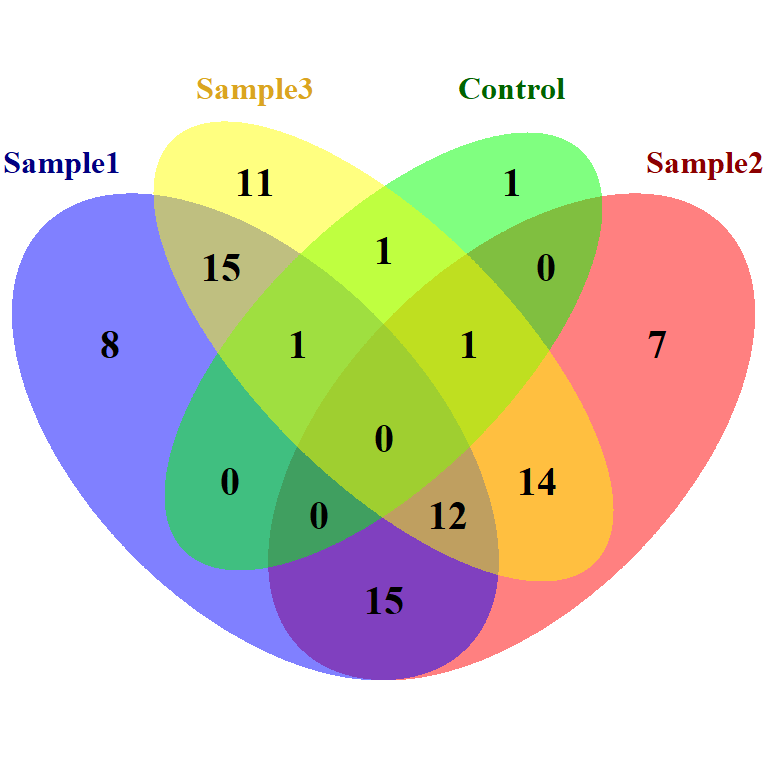

```r
library(VennDiagram)

# Input is list of IDs
ID_list <- list(Sample1=sig1$IDs, Sample2=sig2$IDs, Sample3=sig3$IDs, Control=sigcntl$IDs)

myVenn <- venn.diagram(x=ID_list[1:4], filename = NULL,
                     fill = c("blue", "red", "yellow", "green"), alpha = 0.5, col="transparent",
                     cex = 1.25, fontface="bold", # Intersection label size and style
                     cat.fontface="bold", cat.cex = 1, # Category name size and style
                     cat.col = c("navy", "darkred", "goldenrod", "darkgreen"))

grid.newpage()
grid.draw(myVenn)
```

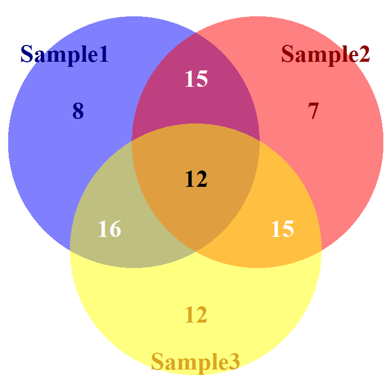

```r
myVenn <- venn.diagram(x=ID_list[1:3], filename = NULL, fill = c("blue", "red", "yellow"),
                     alpha = 0.5, col="transparent",
                     cex = 1.5, fontface="bold", # Intersection label size and style
                     cat.cex=1.5, cat.fontface="bold", # Category name size and style
                     cat.dist=c(-0.01,-0.01,-0.01), # Category name distance from edge of the circle
                     cat.pos = c(325,35,180), # Category name position in degrees
                     cat.col = c("navy", "darkred", "goldenrod"),
                     label.col = c("navy", "white", "darkred", "white", "black", "white", "goldenrod"))

grid.newpage()
grid.draw(myVenn)
```

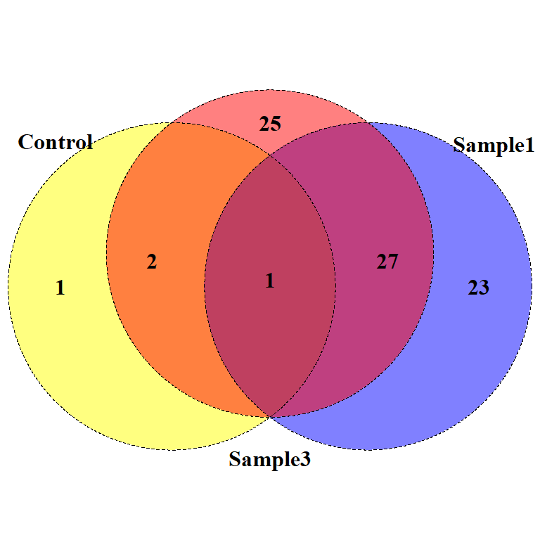

```r
myVenn <- venn.diagram(x=ID_list[c(1,3,4)], fill = c("blue", "red", "yellow"),
                     alpha = 0.5, fontface = "bold",
                     cat.fontface = "bold",
                     lty = "dashed", lwd=0.75,
                     filename = NULL)

grid.newpage()
grid.draw(myVenn)
```

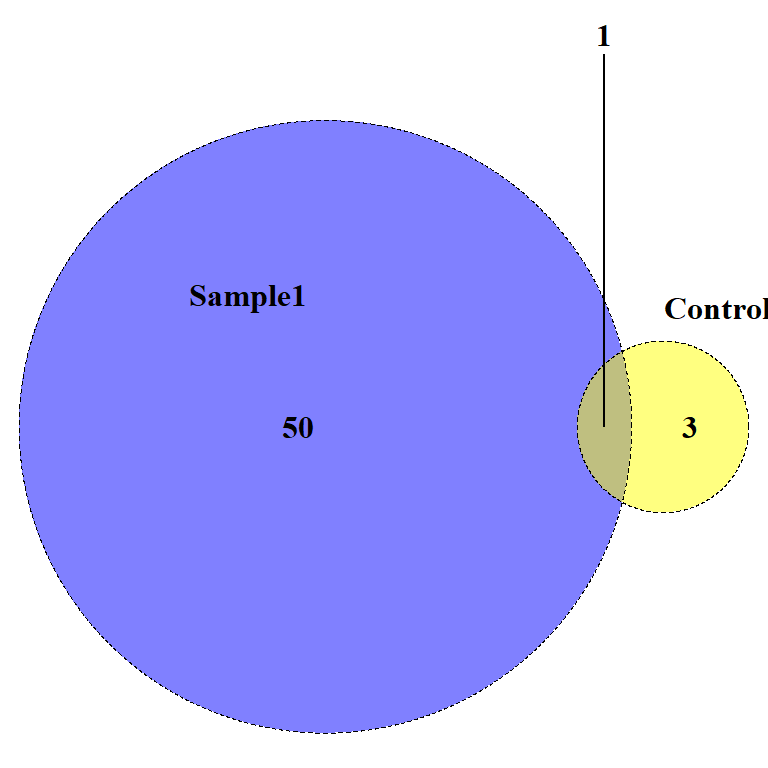

```r
myVenn <- venn.diagram(x=ID_list[c(1,4)], fill = c("blue", "yellow"),
                     alpha = 0.5, fontface = "bold",
                     cat.fontface = "bold",
                     cat.dist = c(-0.1,0.03), cat.pos = c(-30,25),
                     lty = "dashed", lwd=0.75,
                     filename = NULL)

grid.newpage()
grid.draw(myVenn)
```

### Input data: Creating set relationship or count matrix

##### Both Limma and Eulerr do not accept a list of IDs as input. You can easily change a list of IDs into a count matrix. Here is one way to do that:

```r
library(reshape2)

ID_list_m <- melt(ID_list[1:length(ID_list)])
ID_counts <- dcast(ID_list_m, value ~ L1, fun.aggregate = length)

head(ID_counts)
```

```
##      value Control Sample1 Sample2 Sample3
## 1  Gene_10       0       0       1       1
## 2 Gene_100       0       0       1       0
## 3  Gene_11       0       0       1       1
## 4  Gene_12       0       1       0       0
## 5  Gene_13       0       1       0       1
## 6  Gene_14       0       0       0       1
```

### Eulerr

Eulerr’s default settings for creating Euler diagrams are really beautiful. Input data is a count matrix.

https://cran.r-project.org/web/packages/eulerr/vignettes/introduction.pdf

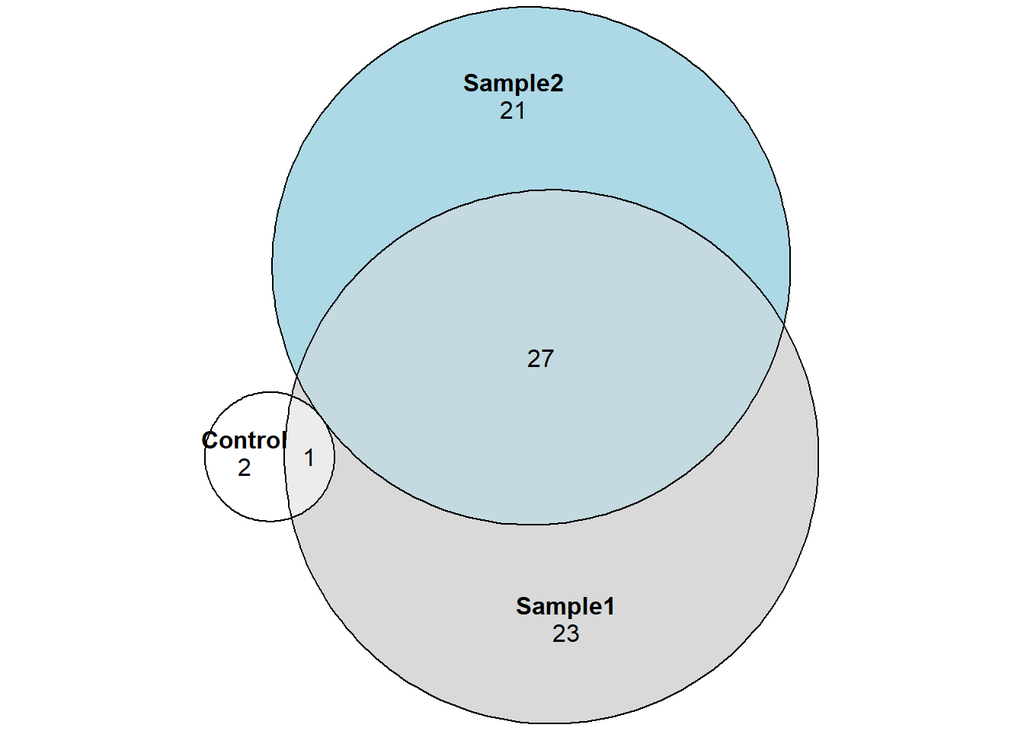

```r
library(eulerr)

# Input is a count matrix
fit <- euler(ID_counts[2:4])
plot(fit, quantities=TRUE)
```

##### However, Eulerr diagrams can be tricky sometimes …

Notice that Eulerr is missing the overlap between Sample 2 and the Control (Gene_39):

| value | Control | Sample1 | Sample2 | Sample3 |
| --- | --- | --- | --- | --- |
| Gene_27 | 1 | 1 | 0 | 1 |
| Gene_30 | 1 | 0 | 0 | 1 |
| Gene_39 | 1 | 0 | 1 | 1 |
| Gene_65 | 1 | 0 | 0 | 0 |

##### Gene_39 is also missing below. Some relationships are difficult to show in euler diagrams.

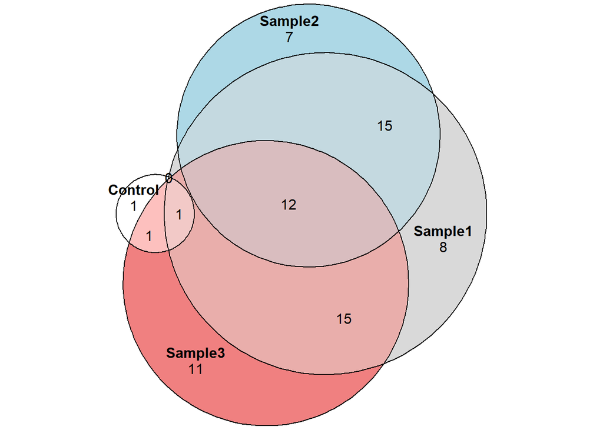

```r
fit <- euler(ID_counts[2:5])
plot(fit, quantities=TRUE)
```

### Limma

https://bioconductor.org/packages/devel/bioc/manuals/limma/man/limma.pdf

Limma’s vennDiagram function can plot up to five sets and accepts a matrix of counts rather than a list of IDs. Click here to see sample data.

Count matrix:

```
##      value Control Sample1 Sample2 Sample3
## 1  Gene_10       0       0       1       1
## 2 Gene_100       0       0       1       0
## 3  Gene_11       0       0       1       1
## 4  Gene_12       0       1       0       0
## 5  Gene_13       0       1       0       1
## 6  Gene_14       0       0       0       1
```

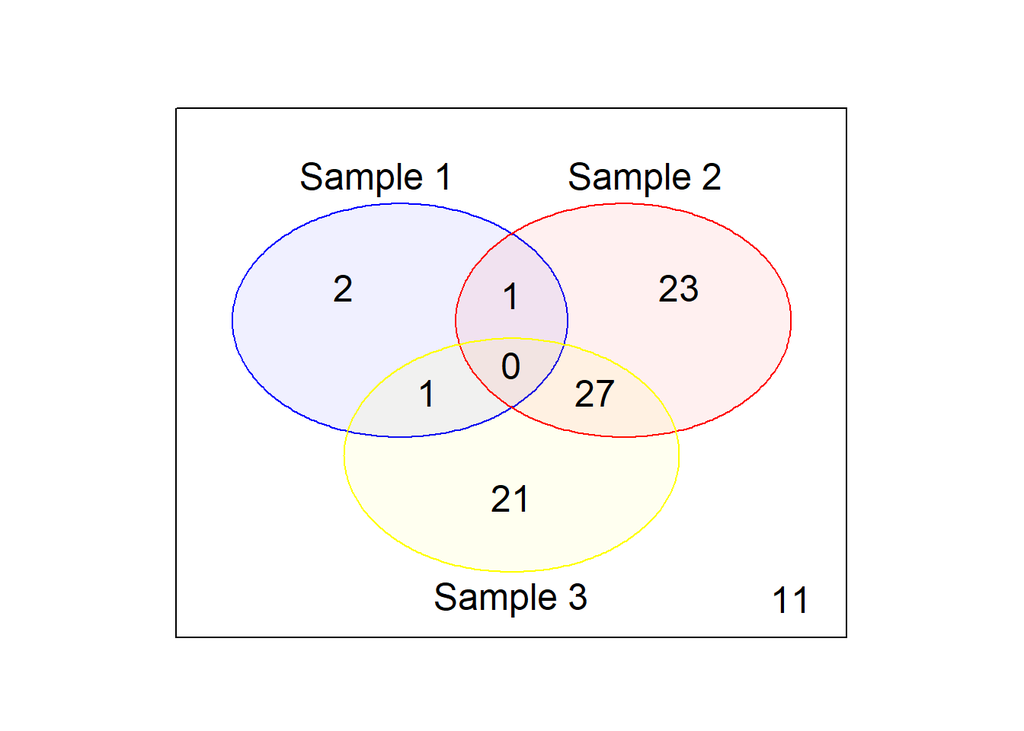

```r
#biocLite("limma")
library("limma")

vennDiagram(ID_counts[2:4], include = "both",
            names = c("Sample 1", "Sample 2", "Sample 3"),
            circle.col=c("blue", "red", "yellow"))
```

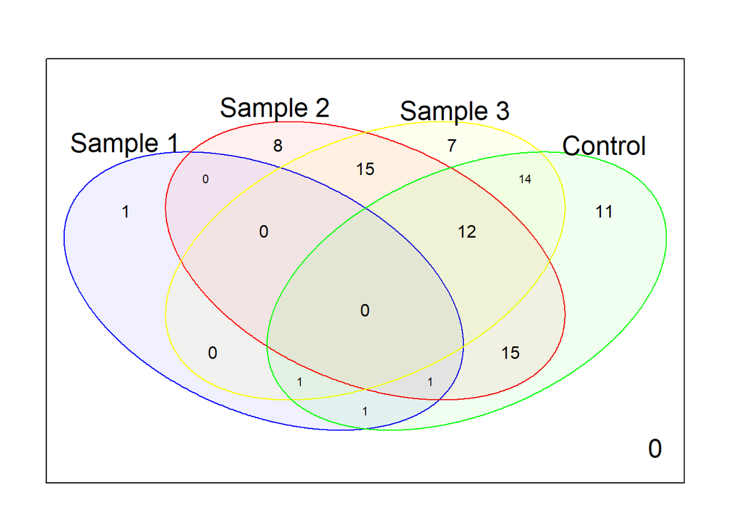

```r
vennDiagram(ID_counts[2:5], include = "both",
            names = c("Sample 1", "Sample 2", "Sample 3", "Control"),
            circle.col=c("blue", "red", "yellow", "green"))
```

Limma was written for processing microarray data and the venn diagram function works well following this pipeline:

```r
fit <- eBayes(lmFit(Y,x))
results <- decideTests(fit)
a <- vennCounts(results)
vennDiagram(a)
```

See https://rdrr.io/bioc/limma/man/ebayes.html for more information

# Non programming solutions

If you just want to make a quick venn diagram, here are some online tools to help you:

- Venny
  - http://www.forestrylab.org/tool/Venny/
  - http://bioinfogp.cnb.csic.es/tools/venny/
  - Up to 4 different sets
  - Not proportional
  - Can include percents or counts
- BioVenn
  - http://www.biovenn.nl/
  - Up to 3 different sets
  - Proportional
- InteractiVenn
  - http://www.interactivenn.net/
  - Up to 6 different sets
  - Not proportional
- Venn by Bioinformatics and Evolutionary Genomics
  - http://bioinformatics.psb.ugent.be/webtools/Venn/
  - Up to 3 different sets